# Assignment 4: Spatial Predictive Analysis

Bias in Burglary Prediction Modeling

Author

Ixchel Ramirez

Published

November 17, 2025

# Crime Analysis in Chicago

## Introduction

This lab looks into the correlation between 311 calls about street lights being out and burglaries. Lighting is often connected to people’s perceptions on safety, people choose to walk a certain way at night because there are more street lights which enable them to see. I wanted to see how this perception of safety connects to burglary calls.

## Chicago Spatial Data

```r
# Load police districts (used for spatial cross-validation)
policeDistricts <-
  st_read("https://data.cityofchicago.org/api/geospatial/24zt-jpfn?method=export&format=GeoJSON") %>%
  st_transform('ESRI:102271') %>%
  dplyr::select(District = dist_num)
# Load police beats (smaller administrative units)
policeBeats <-
  st_read("https://data.cityofchicago.org/api/geospatial/n9it-hstw?method=export&format=GeoJSON") %>%
  st_transform('ESRI:102271') %>%
  dplyr::select(Beat = beat_num)
# Load Chicago boundary
chicagoBoundary <-
  st_read("https://raw.githubusercontent.com/urbanSpatial/Public-Policy-Analytics-Landing/master/DATA/Chapter5/chicagoBoundary.geojson") %>%
  st_transform('ESRI:102271')
cat("✓ Loaded spatial boundaries\n")
```

```
✓ Loaded spatial boundaries
```

```r
cat("  - Police districts:", nrow(policeDistricts), "\n")
```

```
  - Police districts: 25
```

```r
cat("  - Police beats:", nrow(policeBeats), "\n")
```

```
  - Police beats: 277
```

##Loaded in Chicago Spatial data The coordinate reference system is set to ‘ESRI:102271’ (Illinois State Plane East) because it minimizes distortion since all the data we are looking at is in Chicago. Additionally, since Chicago is in the US which feet as a system of measurement it removes the need to convert units and minimizes confusion and error in distance calculations.

## Burglary Data

```r
# Load from provided data file (downloaded from Chicago open data portal)

burglaries <- st_read(here("data", "burglaries.shp"))
burglaries <- st_transform(burglaries, crs = 'ESRI:102271')


# Check the data
cat("\n✓ Loaded burglary data\n")
```

```
✓ Loaded burglary data
```

```r
cat("  - Number of burglaries:", nrow(burglaries), "\n")
```

```
  - Number of burglaries: 7482
```

```r
cat("  - CRS:", st_crs(burglaries)$input, "\n")
```

```
  - CRS: ESRI:102271
```

```r
cat("  - Date range:", min(burglaries$date, na.rm = TRUE), "to",
    max(burglaries$date, na.rm = TRUE), "\n")
```

```
  - Date range: Inf to -Inf
```

There are 7482 burglaries in the data set and the CRS is also set to Chicago which is useful for later calculations that check distance. If the datasets used different coordinate reference systems then problems would arise later when calculating distance. It is important to understand that while there are 7482 burglaries the spatial distribution of these is likely unequal and reflects where crime is surveilled rather than only where crime occurs.

## Visualize point data

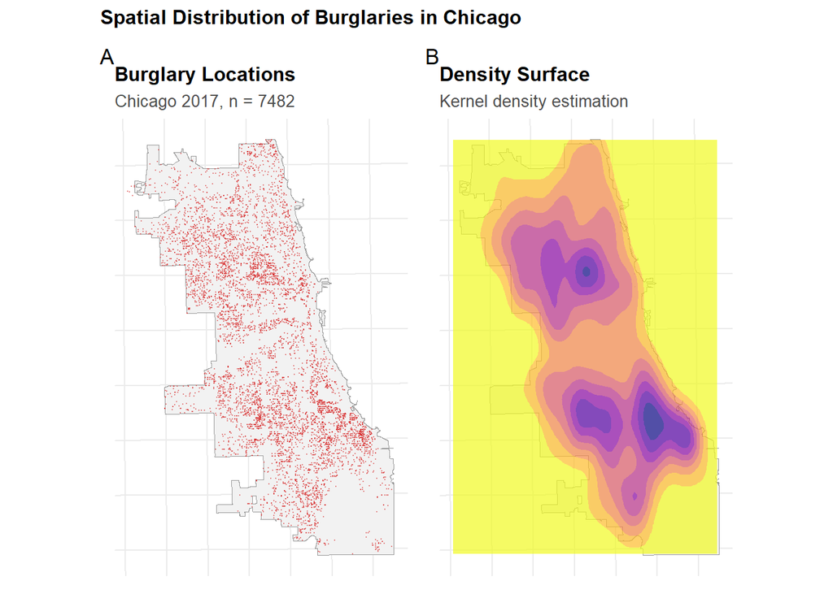

```r
# Simple point map
p1 <- ggplot() +
  geom_sf(data = chicagoBoundary, fill = "gray95", color = "gray60") +
  geom_sf(data = burglaries, color = "#d62828", size = 0.1, alpha = 0.4) +
  labs(
    title = "Burglary Locations",
    subtitle = paste0("Chicago 2017, n = ", nrow(burglaries))
  )

# Density surface using modern syntax
p2 <- ggplot() +
  geom_sf(data = chicagoBoundary, fill = "gray95", color = "gray60") +
  geom_density_2d_filled(
    data = data.frame(st_coordinates(burglaries)),
    aes(X, Y),
    alpha = 0.7,
    bins = 8
  ) +
  scale_fill_viridis_d(
    option = "plasma",
    direction = -1,
    guide = "none"  # Modern ggplot2 syntax (not guide = FALSE)
  ) +
  labs(
    title = "Density Surface",
    subtitle = "Kernel density estimation"
  )

# Combine plots using patchwork (modern approach)
p1 + p2 +
  plot_annotation(
    title = "Spatial Distribution of Burglaries in Chicago",
    tag_levels = 'A'
  )
```